# R Notebook

# SpaceWars - The mysteries of Tabs versus Spaces revealed

## Introduction

Some time last year I was starting out learning Statistical Modelling and I became intrigued by an analysis done on data from the 2017 StackOverflow survey that showed that developers that preferred to indent their code with spaces rather than tabs had a distinct salary advantage. The salary advantage was surprisingly persistence even when you attempted to account for variables like the country the developer worked in or how many years they had been working for.

The problem while somewhat trivial was somewhat intriguing and I took it upon myself to get to the bottom of it. Being a data science newbie at the time it proved far more of a challenge that I expected! However I did learn a hell of a lot in the process.

Currently I’m polishing up a lot of my self-training data analyses to form a portfolio of work I can present to prospective employers. However upon inspection I found this analysis, while it had some good ideas, had some issues. So I decided to revisit it with lessons I’ve learnt upon the way and the techniques I’ve developed since.

# Lets see the mystery

## Data Preparation

I’ve grabbed the data and the data cleaning code and I did back in 2017. It was basically okay but I just tidied it a bit.

I had dropped out all respondants that hadn’t answered both the salary question and the space/tab preference question. Which is a good start.

Many of the questions allowed multiple answers. For instance “What programming languages had you used” allowed you to answer yes to a list of programming questions. Also many questions were missing answers. To deal with this I had split all the possible answers to a question into individual columns. If a question was unanswered then there would be simply be no positives for that question.

The salaries between countries were markedly different. I had scaled the salary for each respondant by his countries mean salary, so all respondants had similar salary ranges, regardless of their country. I now know that these sorts of transformations are common practice.

## Differences in Salary across the board.

So to start lets plot the salaries for all respondants divided into those who prefer to format there code with spaces versus those who prefer tabs.

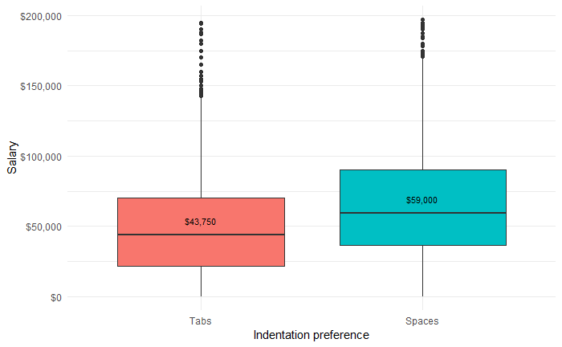

As you can see their is a marked difference in the reported salaries the two.

## Difference between countries

An obvious question that often got raised when I worked on this problem was whether the country the respondant was working on had something to do with it. Maybe people in India had a marked preference and they were earning less?

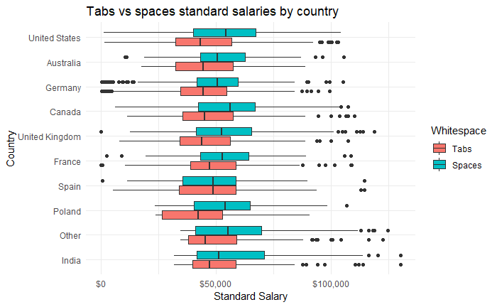

## Difference with years of experience

Another obvious question is perhaps it had to do with how long a respondant had been working for. Maybe a space preference is “Old school” and people who have been working for longer definitly get paid more.

[figure not shown]

Again you can see the salary advantage for preferring spaces is consistent.

# Why is the whitespace preference is important?

That a minor styling difference would have such a persistent widespread effect on respondants wages seems ludicrous. But the interesting question is how do you demonstrate that.

When I first did this problem I spent a great deal of time and effort trying to isolate what variables where really causing the salary difference. I added more and more variables and tried to take into account more and more information, but to no avail.

The whitespace formatting preference was a summary of something and regardless of how many predictors you added or what algorithm you used the machines locked on to that.

Eventually I realized that I had been asking the algorithms the wrong question. I had been trying to predict salaries which contained a hidden assumption that the space preference had a causal effect. I hoped that by pouring more data into the machines they would eventually decide to ignore the information and they never did.

However you can answer the question pretty easily by trying to *predict* the whitespace preference.

## Predicting the white space preference

Back in 2017 I had written an awful lot of code to do the predictive modelling. However now I’ve got a much more sophisticated aresenal of tools, including my emc library.

I’m going to generate a series of predictive models using a variety of algorithms. I’m going to provide answers to the following question in the model.

- What programming languages have you used?
- What development frameworks have you used?
- What databases have you used?
- What platforms have you developed for?
- What IDES have you used?
- What version management system do you use?
- How often do you check in code?
- What development methodology do you use?
- What is the size of the company you work for?
- To what level did you receive formal education?
- What did you major in at uni?
- What type of company do you work for?
- What type of developer are you?
- What is your gender?

As I mentioned previous each of the questions can have multiple answers resulting in multiple variables per question. This list of questions results in something like 200 different variables where most answers values are Zero.

This results in a sparse data set. Consequently we are going to use the algorithms that perform automatic feature selection.

Using emc query I can get all the algorithms that are installed on my workstation that have this property and can be used to solve a two class classication problem.

| algorithm | label | core |
| --- | --- | --- |
| ada | Boosted Classification Trees | TRUE |
| earth | Multivariate Adaptive Regression Spline | TRUE |
| glmnet | Penalized Linear Model | TRUE |
| J48 | C4.5-like Trees | TRUE |
| LMT | Logistic Model Trees | TRUE |
| LogitBoost | Boosted Logistic Regression | TRUE |
| OneR | Single Rule Classification | TRUE |
| rpart | CART | TRUE |
| xgbLinear | eXtreme Gradient Boosting - Linear | TRUE |
| xgbTree | eXtreme Gradient Boosting - Tree | TRUE |

Using emc we fit a predictive model for each algorithm.

```
>>>> Cached Space Preference - Train ada <<<<
>>>> Cached Space Preference - Train earth <<<<
>>>> Cached Space Preference - Train glmnet <<<<
>>>> Cached Space Preference - Train J48 <<<<
>>>> Cached Space Preference - Train LMT <<<<
>>>> Cached Space Preference - Train LogitBoost <<<<
>>>> Cached Space Preference - Train OneR <<<<
>>>> Cached Space Preference - Train rpart <<<<
>>>> Cached Space Preference - Train xgbLinear <<<<
>>>> Cached Space Preference - Train xgbTree <<<<
```

Using emc you can get a status report of how each algorithm did.

| algorithm | label | ROC | Sens | Spec | train_error | train_errors | train_warnings | train_duration |
| --- | --- | --- | --- | --- | --- | --- | --- | --- |
| glmnet | Penalized Linear Model | 0.72 | 0.65 | 0.67 |  | 0 | 0 | 14.75 |
| xgbTree | eXtreme Gradient Boosting - Tree | 0.72 | 0.65 | 0.66 |  | 0 | 0 | 932.75 |
| LMT | Logistic Model Trees | 0.71 | 0.65 | 0.66 |  | 0 | 0 | 712.94 |
| ada | Boosted Classification Trees | 0.71 | 0.35 | 0.35 |  | 0 | 0 | 388.87 |
| earth | Multivariate Adaptive Regression Spline | 0.70 | 0.64 | 0.66 |  | 0 | 0 | 57.78 |
| xgbLinear | eXtreme Gradient Boosting - Linear | 0.70 | 0.64 | 0.65 |  | 0 | 0 | 1380.02 |
| J48 | C4.5-like Trees | 0.65 | 0.63 | 0.62 |  | 0 | 0 | 268.86 |
| rpart | CART | 0.62 | 0.73 | 0.49 |  | 0 | 0 | 14.07 |
| LogitBoost | Boosted Logistic Regression | 0.62 | 0.81 | 0.40 |  | 0 | 0 | 6.54 |
| OneR | Single Rule Classification | 0.58 | 0.68 | 0.48 |  | 0 | 0 | 6.12 |

It looks like random forests didn’t cope with the problem and it fell over after running for 4 hours. Possibly because my laptop overheated after running all 8 virtual cores at 100% for several hours. But emc captured everything else and I’ll continue with what worked.

## The power of a null hypothesis

As I said previously you can do tons of digging in the data and you can’t eliminate that salary advantage that space formatters appear to have.

There are more “Data Sciency” ways of coming to the same conclusion. But I thought this way had a nice intuitive feel to it.

# So what the hell *is* going on?

As well as the predictions another piece of information provided by all those predictive models is how important each of the variables was in that algorithms prediction. The following plot shows the importance rating provided by each algorithm for those variables that had a median rating in the top 20.

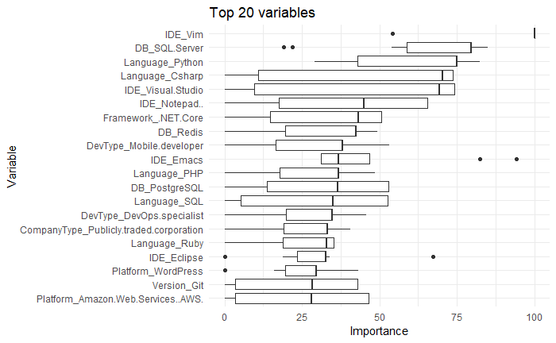

Hmmmm.

Overall I think the story that makes sense is this:

There is a tendancy for developers to form a white space preference as a consequence of the development tools they use, in particular the IDE. Different industries tend to use different tool sets and I can tell you developers get paid differently depending on what industry they work in.

| Question | Feature | n | Standard.Salary | Space.Logodds | Space.odds | Space.probability | Tech.Family | Family_n |
| --- | --- | --- | --- | --- | --- | --- | --- | --- |
| CompanySize | 1.000.to.4.999.employees | 1061 | 52010.60 | 0.0591995378 | 1.0609869 | 0.5147956 | SQL, Visual.Studio, Csharp | 334 |
| CompanySize | 10.000.or.more.employees | 1477 | 55651.61 | 0.3001679630 | 1.3500856 | 0.5744836 | Java, IntelliJ, Eclipse | 422 |
| CompanySize | 10.to.19.employees | 1077 | 43760.34 | -0.0630550322 | 0.9388918 | 0.4842415 | JavaScript, MySQL, Vim | 385 |
| CompanySize | 100.to.499.employees | 2094 | 50794.73 | 0.0511774282 | 1.0525096 | 0.5127916 | SQL, Visual.Studio, Csharp | 693 |
| CompanySize | 20.to.99.employees | 2448 | 47087.35 | 0.0061941547 | 1.0062134 | 0.5015485 | JavaScript, MySQL, Vim | 674 |
| CompanySize | 5.000.to.9.999.employees | 416 | 50751.02 | 0.1599559021 | 1.1734591 | 0.5399039 | SQL, Visual.Studio, Csharp | 108 |
| CompanySize | 500.to.999.employees | 705 | 50000.00 | -0.0399928778 | 0.9607963 | 0.4900031 | SQL, Visual.Studio, Csharp | 234 |
| CompanySize | Fewer.than.10.employees | 966 | 42598.19 | -0.1834862480 | 0.8323633 | 0.4542567 | JavaScript, MySQL, Vim | 358 |
| CompanySize | I.don.t.know | 121 | 43315.66 | -0.0310802228 | 0.9693978 | 0.4922306 | SQL, Visual.Studio, Csharp | 35 |
| CompanySize | I.prefer.not.to.answer | 27 | 46779.29 | -0.1940715205 | 0.8235990 | 0.4516338 | Python, Cpp, C | 8 |

[output cut: 224 more lines]

| Question | Space.probability.iqr | Salary.iqr |
| --- | --- | --- |
| Version | 0.25289245 | 10357.885 |
| Language | 0.21705501 | 5851.432 |
| Framework | 0.20066217 | 4626.009 |
| DB | 0.15696689 | 2688.397 |
| IDE | 0.15485765 | 5161.755 |
| Platform | 0.15154280 | 5517.027 |
| TechFamily | 0.14918332 | 4333.072 |
| DevType | 0.11807678 | 3969.969 |
| FormalEducation | 0.11375768 | 6559.226 |
| Country | 0.08506605 | 0.000 |

[output cut: 6 more lines]

## Language Summary

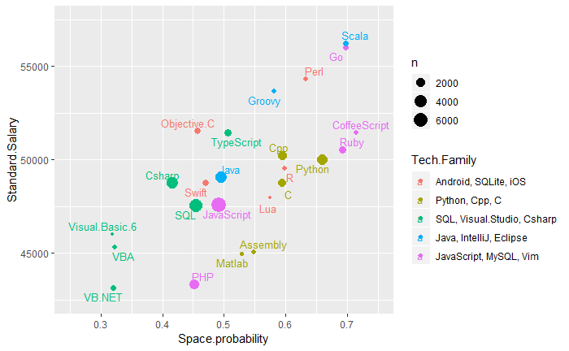

## IDE Summary

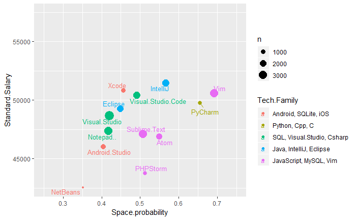

## Platform Summary

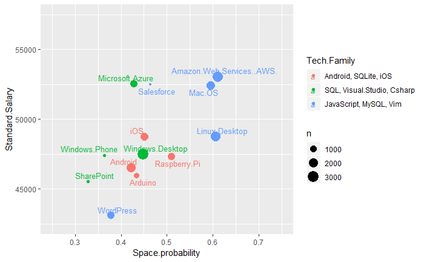

## Version Summary

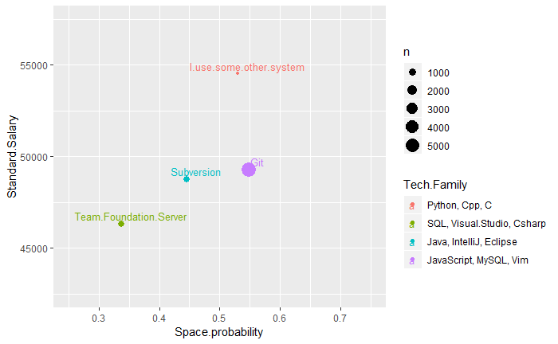

## Database Summary

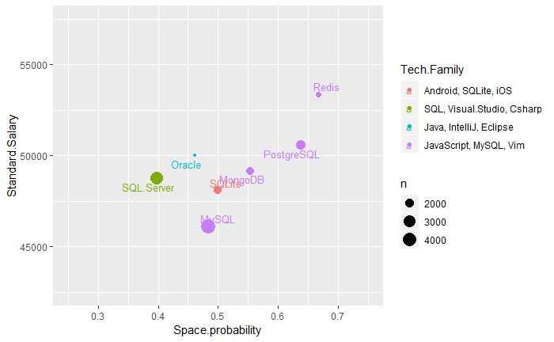

## Company Size

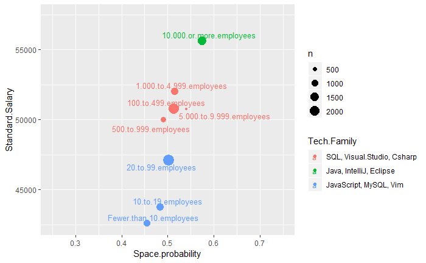

## Self Taught Type

[figure not shown]